# 8.python编程和数据分析基础

## 一、关于

- 同学情况调查
- 厦门大学计量经济学教育部重点实验室（部重室 微信号）和厦门大学数据科学与决策咨询研究中心
  - 旨在加强厦门大学经济学科教学和科研能力，提高信息技术和数据科学方面的能力
  - 探索理工类科实验室培养学生的模式，探索产学研结合的数据科学能力提升的路径
    - 编程基础培训，数据科学讨论班，教师科研助理，科研课题训练，企业实习
  - 建设数据中心：为师生提供数据、计算和应用开发服务，运维数据中心基础设施
    - HPC集群
    - 数据共享和计算平台
- WISER Club 微信号

## 二、关于python

python是一门编程语言，与任何一门语言一样需要与业务领域结合才能发挥作用。python的学习不在于编程，在于应用。但是我们往往采用传统方式来学习一门编程语言，即构建知识树。我们先来看看python的知识全景

### 1. 知识树展示python知识体系

在python的知识体系图中可以发现，已经出现如java语言那样坚实稳定的基础，至少我们可以放心学习一门不那么快被淘汰的编程语言，但是仅仅数据科学方向上python的知识体系已经相当复杂了

[figure not shown]

在更加广义上python所涉及的数据科学领域，还需要更加丰富的知识体系。数据科学是一门综合型和实验性都很强的学科，在项目实践中，一个人单打独斗的日子可能已经一去不复返了，知识互补的团队作战才能。

[figure not shown]

然而知识互补不代表你可以不了解你同伴的工作，你可以专注于你的方向，但是其他方向你多少还是需要有所了解

```python
import numpy as np
import pandas as pd
import matplotlib.pyplot as plt
%matplotlib inline
```

```
<Container object of 7 artists>
```

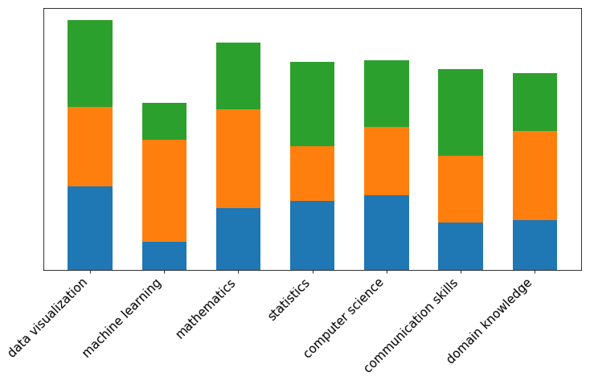

```python
n = 7
np.random.seed(123)
y = np.random.randint(20, 80, size=n)
fig, axs = plt.subplots(1, figsize=(12,6))
labels = ['data visualization', 'machine learning', 'mathematics', 'statistics',
          'computer science', 'communication skills', 'domain knowledge']
x = range(n)
plt.bar(x, y, width=0.6, tick_label = labels);
for label in axs.get_xmajorticklabels():
    label.set_rotation(45)
    label.set_fontsize(15)
    label.set_horizontalalignment("right")

axs.get_yaxis().set_visible(False)

z = np.random.randint(20, 80, size=n)
plt.bar(x, z, bottom=y, width=0.6)

w = np.random.randint(20, 80, size=n)
plt.bar(x, w, bottom=y + z, width=0.6)
```

上面不同颜色代表你的团队成员，他们需要各方面知识。

### 2. 问题树渐进掌握python知识体系

我们是否可以尝试另一种方式来学习python，构建python学习的问题树

- 有时提出问题比解决问题更重要
- 有时解决问题比记住知识更重要

画上面那幅图柱形图有没有更简单的画法？如果问题太难，我们先找简单的，比如后面提到生成数列或者处理歌词等

以我自己的编程方面的学习经历，大概的流程是这样

- 了解背景知识
- 提出需要解决的问题
- 学习相关知识
- 尝试解决问题
- 发现更多需要解决的子问题
- 检查子问题是不是脱离父问题太远，太远暂时放弃，不远则解决
- 递归直到大体解决问题
- 重构优化解决方案
- 重复以上流程

把被动的学习知识点转变为解决具体问题

### 3. 关于python的背景知识

#### （1） TIOBE编程语言排名

http://www.tiobe.com/tiobe-index/

Python和其他许多语言都是很老的语言，上个世纪90年代是语言的爆发期，Java、Python、PHP、Ruby都是那个时代的产物。 Python并不是近年才火，只是在数据时代，大家又发现了Python新的价值。

[figure not shown]

#### （2）为什么选择python?

- 排名前10中最容易入门的语言
- Python涉及领域多：Web应用开发，桌面应用开发，嵌入式开发，数据科学
- Python是胶水语言：直接调用C、Java和C#库（CPython，Jython，IronPython）
- Python库多：Python某个功能的库可能比Python语言的关键字还多
- Python开源
- Python有做数据科学的潜质，与R并驾齐驱

Life is short , You need Python

[figure not shown]

#### （3）python家族

- CPython：用C编写的Python解释器，是Python的参考实现。CPython为Python包和C扩展模块提供了最大限度的兼容
- Jython：Java平台上实现的Python解释器，Python代码运行在JVM上，可以像是用Python模块一样，导入 并使用任何Java类
- IronPyton：.Net平台上实现的Python解释器
- MicroPython：支持嵌入式系统
- PyPy(JIT)：用RPython实现的解释器，RPython是Python的子集

#### （4）解释型还是编译型?

针对CPython而言

- 源代码（.py）
- 字节码（.pyc）：有写入权限则生成编译后的pyc文件
- 机器码（二进制）

由于跨平台和效率的需要，Python源代码会自动编译成字节码（Python与Java和C#的字节码类似但不同）。 所有语言最终都需要编译成为机器码（机器码不是汇编，C语言编译为汇编而后编译为机器码）。 CPU指令集解释机器码。

#### （5）第三方包

- flask:
  - Flask is a microframework for Python. http://flask.pocoo.org
- django:
  - Django is a high-level Python Web framework that encourages rapid development and clean, pragmatic design. https://www.djangoproject.com
- requests:
  - Python HTTP Requests for Humans. http://python-requests.org
- pyspider:
  - A Powerful Spider(Web Crawler) System in Python. http://docs.pyspider.org
- numpy:
  - NumPy is the fundamental package for scientific computing with Python. http://www.numpy.org
- scipy:
  - SciPy is open-source software for mathematics, science, and engineering. https://www.scipy.org
- pandas:
  - pandas is an open source, BSD-licensed library providing high-performance, easy-to-use data structures and data analysis tools for the Python programming language. http://pandas.pydata.org
- matplotlib:
  - Matplotlib is a Python 2D plotting library. http://matplotlib.org
- seaborn:
  - Seaborn is a Python visualization library based on matplotlib. It provides a high-level interface for drawing attractive statistical graphics. https://seaborn.pydata.org
- statsmodels:
  - statsmodels is a Python module that provides classes and functions for the estimation of many different statistical models, as well as for conducting statistical tests, and statistical data exploration. http://www.statsmodels.org
- scikit-learn:
  - Simple and efficient tools for data mining and data analysis. http://scikit-learn.org
- theano:
  - Theano is a Python library that allows you to define, optimize, and evaluate mathematical expressions involving multi-dimensional arrays efficiently. http://deeplearning.net/software/theano/
- tensorflow:
  - TensorFlow is an open source software library for numerical computation using data flow graphs. https://www.tensorflow.org/
- keras
  - Keras is a high-level neural networks API, written in Python and capable of running on top of either TensorFlow or Theano. https://keras.io/ http://keras-cn.readthedocs.io

#### （6）python版本和anaconda

- python 2和python 3：python 2.7作为标准有很长一段时间，python 3正在赶超（对中文等unicode字符支持更好），根据实际需要进行选择，本课件使用python 3，对于初学者，其实有更重要的东西要操心
- x64和x86：与操作系统相关，有些python包对该版本有要求，推荐使用64位的python 3.6
- 下载和安装python
- anaconda是一个用于科学计算的Python发行版，支持 Linux, Mac, Windows系统，提供了包管理与环境管理的功能，可以很方便地解决多版本python并存、切换以及各种第三方包安装问题。 下载地址https://www.continuum.io/downloads

#### （7）python开发工具和jupyter notebook

python开发可以使用集成开发环境（IDE），也可以使用简单的文本编辑器，也可以使用jupyter notebook这样的交互工具，根据需要而定。一般而言集成开发环境用在大中型项目中，能够提高开发效率。

- Spyder
- PyCharm
- Eclipse + PyDev
- Visual Studio + Python Tools
- VSCode
- Sublime
- Notepad++
- Atom
- Jupyter notebook(IPython)

## 三、关于编程

### 1. 程序员思维

- Python语言更偏向程序员思维
- 一切都是输入输出的盒子
- 盒子有两种，功能盒子和数据盒子
- 创造、改进、使用这个盒子（抽象、重构、调用）
- 努力不重复自己
- 多模仿
- 多敲代码

### 2. 学习曲线

编程是一种解决问题的方法，本质上看重的是问题的解决和能力的提升，会回调与人的记忆模式有关

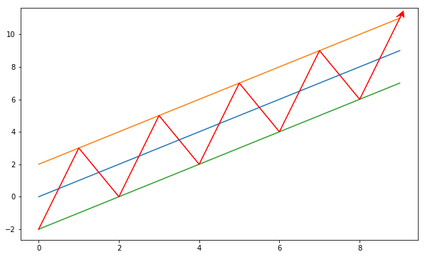

```python
x = np.arange(10)
plt.figure(figsize=(10,6))
plt.plot(x, x)
plt.plot(x, x + 2)
plt.plot(x, x - 2)
y = np.array([n - 2 if n % 2 == 0 else n + 2 for n in x])
plt.plot(x, y, 'r')
plt.arrow(9, 11, (x[9]-x[8])*0.01, (y[9]-y[8])*0.01, head_width=0.2, head_length=0.4, fc='r', ec='r',overhang=0.4)
plt.show()
```

### 3. 编程的附加值

- Kenneth Reitz
- Requests: HTTP for Humans
- http://python-requests.org
- https://github.com/kennethreitz/requests

[figure not shown]

```python
import requests
r = requests.get("https://www.baidu.com")
r.text
```

```
'<!DOCTYPE html>\r\n<!--STATUS OK--><html> <head><meta http-equiv=content-type content=text/html;charset=utf-8><meta http-equiv=X-UA-Compatible content=IE=Edge><meta content=always name=referrer><link rel=stylesheet type=text/css href=https://ss1.bdstatic.com/5eN1bjq8AAUYm2zgoY3K/r/www/cache/bdorz/b…
```

## 四、编程起步

### 1. 提出问题

#### （1）开始使用jupyter notebook

#### （2）找出一段英文歌词中出现次数最多的单词

### 2. 相关知识

#### （1）python基本语法

需要了解部分语法结构、数据类型和控制语句

#### （2）python字符串处理

字符串定义和方法（觉得正则表达式太难，放弃以后再说）

### 3. 解决问题

```python
import re
s = '''
When I am down and, oh, my soul, so weary;
When troubles come and my heart burdened be;
Then I am still and wait here in the silence,
Until you come and sit awhile with me.
You raise me up, so I can stand on mountains;
You raise me up to walk on stormy seas;
I am strong when I am on your shoulders;
You raise me up to more than I can be.
You raise me up, so I can stand on mountains;
You raise me up to walk on stormy seas;
You raise me up to walk on stormy seas;
I am strong when I am on your shoulders;
You raise me up to more than I can be.
There is no life - no life without its hunger;
Each restless heart beats so imperfectly;
But when you come and I am filled with wonder,
Sometimes, I think I glimpse eternity.
You raise me up, so I can stand on mountains;
You raise me up to walk on stormy seas;
I am strong when I am on your shoulders;
You raise me up to more than I can be.
You raise me up, so I can stand on mountains;
You raise me up to walk on stormy seas;
I am strong when I am on your shoulders;
You raise me up to more than I can be.
You raise me up to more than I can be.'''
words = re.split('[^a-zA-Z]+', s)
```

```python
word_counts = {}
for word in words:
    if word not in word_counts:
        word_counts[word] = 1
    else:
        word_counts[word] += 1

word_counts = sorted(word_counts.items(), key=lambda x: x[1], reverse = True)
word_counts[0:5]
```

```
[('I', 22), ('me', 15), ('You', 14), ('raise', 14), ('up', 14)]
```

### 4. 重构优化方案

学习过程中，了解是否有更多的解决方案，前人是不是已经造好了解决问题的盒子，暂时不理解盒子内部机制也没关系

```python
from collections import Counter
word_counts = Counter(words)
word_counts.most_common(5)
```

```
[('I', 22), ('me', 15), ('You', 14), ('raise', 14), ('up', 14)]
```

```python
from pandas import Series
data = Series(words)
c = data.value_counts()
c.ix[0:5]
```

```
I        22
me       15
raise    14
You      14
up       14
dtype: int64
```

## 五、编程进阶

### 1. 提出问题

#### （1）下载网易公开课视频

#### （2）老妈的广场舞视频能不能一起解决

### 2. 相关知识

#### （1）爬虫基础知识

http协议基础，网页基础（html和css还可以，JavaScript先算了）

#### （2）python爬虫相关包

requests和pyquery先来，urllib和beautifulsoap先算了

#### （3）了解一点数据库

sqlite或者mysql

### 3. 解决问题

```python
import requests
import re
from pyquery import PyQuery as pq

key = '如何掌控你的自由时间'
baiduUrl = 'https://www.baidu.com/s?wd=%s site:open.163.com'
flvUrl = 'http://www.flvcd.com/parse.php?format=&kw=%s'
headers = {"User-Agent": "Mozilla/5.0 (Windows NT 10.0; Win64; x64) '\
        'AppleWebKit/537.36 (KHTML, like Gecko) Chrome/58.0.3029.110 Safari/537.36"}
resp = requests.get(baiduUrl % key, headers=headers)
page = pq(resp.text)
items = [(item('a').attr('href'), item('div[.c-span-last]').text())
         for item in  page('div.c-container h3 a.anchor-link').items()]

videoPageUrl = ''
if(len(items) > 0):
    firstResp = requests.get(items[0][0], allow_redirects=False, headers=headers)
    if(firstResp.status_code == 302):
        videoPageUrl = firstResp.headers.get('location')
    elif(firstResp.status_code == 200):
        matchGroup = re.search(r'URL=\'(.*?)\'', firstResp.text, re.S)
        videoPageUrl = matchGroup.group(1)
        print(videoPageUrl)
    if videoPageUrl:
        flvResp = requests.get(flvUrl % videoPageUrl, headers=headers)
        flvPage = pq(flvResp.text)
        flvItems = [item.attr('href') for item in flvPage('td.mn a.link').items()]
        if(len(flvItems) > 0 and flvItems[0]):
            videoUrl = flvItems[0]
            print(videoUrl)
            if videoUrl:
                downResp = requests.get(videoUrl, stream=True)
                fileName = 'video/%s.flv' % key
                with open(fileName, "wb") as file:
                    #file.write(downResp.content)
                    print('finish')
```

### 4. 重构优化方案

要下载多个视频，还要解决老妈的视频下载问题，上面的数据和代码逻辑太混乱了，不好控制，试试面向对象编程进行重构

```python
import requests
import re
from pyquery import PyQuery as pq

class OnlineVideoCrawler(object):
    def __init__(self, keys):
        self.keys = keys
        self.baiduUrl = 'https://www.baidu.com/s?wd=%s site:open.163.com'
        self.flvUrl = 'http://www.flvcd.com/parse.php?format=&kw=%s'
        self.headers = {"User-Agent": "Mozilla/5.0 (Windows NT 10.0; Win64; x64) '\
        'AppleWebKit/537.36 (KHTML, like Gecko) Chrome/58.0.3029.110 Safari/537.36"}

    def getVideoPageUrlFromBaidu(self, key):
        resp = requests.get(self.baiduUrl % key, headers=self.headers)
        page = pq(resp.text)
        items = [(item('a').attr('href'), item('div.c-span-last').text())
                 for item in  page('div.c-container div.c-gap-top-small').items()]
        videoPageUrl = ''
        if(len(items) > 0):
            firstResp = requests.get(items[0][0], allow_redirects=False, headers=self.headers)
            if(firstResp.status_code == 302):
                videoPageUrl = firstResp.headers.get('location')
            elif(firstResp.status_code == 200):
                matchGroup = re.search(r'URL=\'(.*?)\'', firstResp.text, re.S)
                videoPageUrl = matchGroup.group(1)
        print(videoPageUrl)
        return videoPageUrl


    def getVideoUrlFromFlv(self, key):
        videoPageUrl = self.getVideoPageUrlFromBaidu(key)
        videoUrl = ''
        if videoPageUrl:
            flvResp = requests.get(self.flvUrl % videoPageUrl, headers=self.headers)
            flvPage = pq(flvResp.text)
            flvItems = [item.attr('href') for item in flvPage('td.mn a.link').items()]
            if(len(flvItems) > 0 and flvItems[0]):
                videoUrl = flvItems[0]
        print(videoUrl)
        return videoUrl

    def downloadVideo(self, key):
        videoUrl = self.getVideoUrlFromFlv(key)
        downResp = requests.get(videoUrl, stream=True)
        total = int(downResp.headers.get('content-length'))
        print(total)
        fileName = '%s.flv' % key
        i = 0
        chunk_size = 1024
        with open(fileName, "wb") as file:
            for chunk in downResp.iter_content(chunk_size=chunk_size):
                if chunk:
                    i += 1
                    file.write(chunk)
                    file.flush()
                    print('%.2f' % (chunk_size * i / total), end='\r')

    def downloadVideos(self):
        if len(self.keys) > 0:
            for key in self.keys:
                try:
                    self.downloadVideo(key)
                except Exception as e:
                    print(e)

#if __name__ == '__main__':
keys = ['如何掌控你的自由时间','阅读全世界','如何做得更好']
crawler = OnlineVideoCrawler(keys)
#crawler.downloadVideos()
```

## 六、数据探索

### 1. 提出问题

探索一下世界主要城市人口数据

### 2. 相关知识

#### （1）数据分析基础

#### （2）numpy、pandas和matplotlib

### 3. 解决问题

```python
df_pop = pd.read_csv('data/ch05/cities.csv')
df_pop.head()
```

|  | Rank | City | State | Population | Date of census/estimate |
| --- | --- | --- | --- | --- | --- |
| 0 | 1 | London[2] | United Kingdom | 8,615,246 | 1 June 2014 |
| 1 | 2 | Berlin | Germany | 3,437,916 | 31 May 2014 |
| 2 | 3 | Madrid | Spain | 3,165,235 | 1 January 2014 |
| 3 | 4 | Rome | Italy | 2,872,086 | 30 September 2014 |
| 4 | 5 | Paris | France | 2,273,305 | 1 January 2013 |

```python
df_pop.info()
```

```
<class 'pandas.core.frame.DataFrame'>
RangeIndex: 105 entries, 0 to 104
Data columns (total 5 columns):
Rank                       105 non-null int64
City                       105 non-null object
State                      105 non-null object
Population                 105 non-null object
Date of census/estimate    105 non-null object
dtypes: int64(1), object(4)
memory usage: 4.2+ KB
```

```python
type(df_pop.Population[0]) # 不是数字是字符串
```

```
str
```

```python
df_pop["NumericPopulation"] = df_pop.Population.apply(lambda x: int(x.replace(',', '')))
df_pop.head()
```

|  | Rank | City | State | Population | Date of census/estimate | NumericPopulation |
| --- | --- | --- | --- | --- | --- | --- |
| 0 | 1 | London[2] | United Kingdom | 8,615,246 | 1 June 2014 | 8615246 |
| 1 | 2 | Berlin | Germany | 3,437,916 | 31 May 2014 | 3437916 |
| 2 | 3 | Madrid | Spain | 3,165,235 | 1 January 2014 | 3165235 |
| 3 | 4 | Rome | Italy | 2,872,086 | 30 September 2014 | 2872086 |
| 4 | 5 | Paris | France | 2,273,305 | 1 January 2013 | 2273305 |

```python
df_pop["State"].values[:3] #存在多余空格
```

```
array([' United Kingdom', ' Germany', ' Spain'], dtype=object)
```

```python
df_pop["State"] = df_pop["State"].apply(lambda x: x.strip())
df_pop.head()
```

|  | Rank | City | State | Population | Date of census/estimate | NumericPopulation |
| --- | --- | --- | --- | --- | --- | --- |
| 0 | 1 | London[2] | United Kingdom | 8,615,246 | 1 June 2014 | 8615246 |
| 1 | 2 | Berlin | Germany | 3,437,916 | 31 May 2014 | 3437916 |
| 2 | 3 | Madrid | Spain | 3,165,235 | 1 January 2014 | 3165235 |
| 3 | 4 | Rome | Italy | 2,872,086 | 30 September 2014 | 2872086 |
| 4 | 5 | Paris | France | 2,273,305 | 1 January 2013 | 2273305 |

```python
df_pop2 = df_pop.set_index("City")
df_pop2 = df_pop2.sort_index()
df_pop2.head()
```

| City | Rank | State | Population | Date of census/estimate | NumericPopulation |
| --- | --- | --- | --- | --- | --- |
| Aarhus | 92 | Denmark | 326,676 | 1 October 2014 | 326676 |
| Alicante | 86 | Spain | 334,678 | 1 January 2012 | 334678 |
| Amsterdam | 23 | Netherlands | 813,562 | 31 May 2014 | 813562 |
| Antwerp | 59 | Belgium | 510,610 | 1 January 2014 | 510610 |
| Athens | 34 | Greece | 664,046 | 24 May 2011 | 664046 |

```python
df_pop3 = df_pop.set_index(["State", "City"]).sortlevel(0) # 根据第一个索引State排序
df_pop3.head()
```

| State | City | Rank | Population | Date of census/estimate | NumericPopulation |
| --- | --- | --- | --- | --- | --- |
| Austria | Vienna | 7 | 1,794,770 | 1 January 2015 | 1794770 |
| Belgium | Antwerp | 59 | 510,610 | 1 January 2014 | 510610 |
|  | Brussels[17] | 16 | 1,175,831 | 1 January 2014 | 1175831 |
| Bulgaria | Plovdiv | 84 | 341,041 | 31 December 2013 | 341041 |
|  | Sofia | 14 | 1,291,895 | 14 December 2014 | 1291895 |

```python
df_pop3.ix["Belgium"]
```

| City | Rank | Population | Date of census/estimate | NumericPopulation |
| --- | --- | --- | --- | --- |
| Antwerp | 59 | 510,610 | 1 January 2014 | 510610 |
| Brussels[17] | 16 | 1,175,831 | 1 January 2014 | 1175831 |

```python
df_pop.ix[df_pop.State == 'Belgium'] #State没被设置为索引时，使用布尔型索引过滤
```

|  | Rank | City | State | Population | Date of census/estimate | NumericPopulation |
| --- | --- | --- | --- | --- | --- | --- |
| 15 | 16 | Brussels[17] | Belgium | 1,175,831 | 1 January 2014 | 1175831 |
| 58 | 59 | Antwerp | Belgium | 510,610 | 1 January 2014 | 510610 |

```python
df_pop.State.value_counts()
```

```
Germany                     19
United Kingdom              16
Spain                       13
Italy                       10
Poland                      10
France                       5
Netherlands                  4
Romania                      3
Sweden                       3
Bulgaria                     3
Lithuania                    2
Greece                       2
Belgium                      2
Denmark                      2
Czech Republic               2
Ireland                      1
Slovakia Slovak Republic     1
Estonia                      1
Portugal                     1
Latvia                       1
Austria                      1
Finland                      1
Hungary                      1
Croatia                      1
Name: State, dtype: int64
```

```python
df_pop4 = df_pop[["State", "City", "NumericPopulation"]].set_index(["State", "City"])
df_pop4.head()
```

| State | City | NumericPopulation |
| --- | --- | --- |
| United Kingdom | London[2] | 8615246 |
| Germany | Berlin | 3437916 |
| Spain | Madrid | 3165235 |
| Italy | Rome | 2872086 |
| France | Paris | 2273305 |

```python
df_pop5 = df_pop4.sum(level="State").sort_values("NumericPopulation", ascending=False)
df_pop5.head()
```

| State | NumericPopulation |
| --- | --- |
| United Kingdom | 16011877 |
| Germany | 15119548 |
| Spain | 10041639 |
| Italy | 8764067 |
| Poland | 6267409 |

```python
#State没被设置为索引时，可以使用groupby
df_pop6 = df_pop.drop("Rank", axis=1).groupby("State").sum().sort_values("NumericPopulation", ascending=False)
df_pop6.head()
```

| State | NumericPopulation |
| --- | --- |
| United Kingdom | 16011877 |
| Germany | 15119548 |
| Spain | 10041639 |
| Italy | 8764067 |
| Poland | 6267409 |

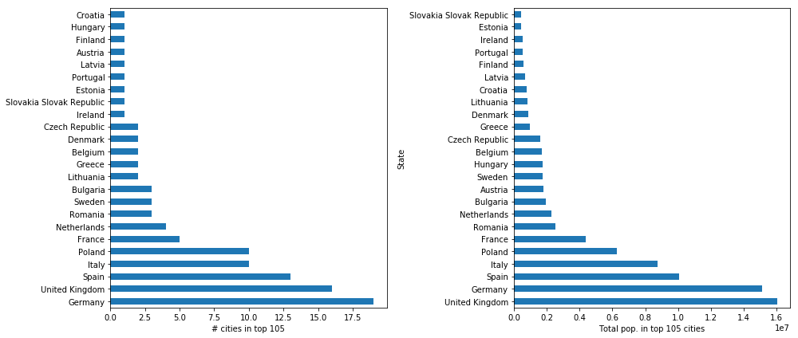

```python
fig, (ax1, ax2) = plt.subplots(1, 2, figsize=(14, 6))
df_pop.State.value_counts().plot(kind='barh', ax=ax1)
ax1.set_xlabel("# cities in top 105")
df_pop6.NumericPopulation.plot(kind='barh', ax=ax2)
ax2.set_xlabel("Total pop. in top 105 cities")
fig.tight_layout()
```

## 七、数据分析

从数据中提取信息，从信息中发现知识，从知识中做出决策

### 1. 背景知识

#### 数据科学工作流程

[figure not shown]

#### 算法和模型

某种程度上是一样的东西，统计学和计算机科学并行发展的历史遗留问题。所以有特征和标签、自变量和因变量、解释变量和目标变量这样对同样东西的不同说法。

3个基础算法：

- 线性回归模型：预测算法，表示变量间的数学关系
- k近邻模型（KNN）：分类算法，给定已经做好分类的数据集，k近邻学习其中的分类信息，并对尚未分类的类似数据进行分类
- k均值模型（K-Means）：聚类算法，没有分类的数据集，算法给出其分类

#### 建模基本步骤

- 问题定义
- 数据探索
- 特征工程
- 建模和评估

### 2. 提出问题

#### 判断一个贷款者在后续两年内是否会违约的概率

案例来自kaggle上一个经典的问题，http://www.kaggle.com/c/GiveMeSomeCredit

#### 分解问题

- 损失是如何发生的?
- 违约的人有哪些特点?
- 违约的占比有多少？
- 如何能改善我们的损失？

### 3. 相关知识

#### （1）数据分析基础，基本统计模型和算法实现

#### （2）numpy,pandas,matplotlib,sklearn包

### 4. 解决问题

#### （1）数据探索

- SeriousDlqin2yrs
  - 用户在后续两年内出现90天以上的还款逾期，这是目标变量，以下都是解释变量
- NumberRealEstateLoansOrLines
  - 房贷的信贷次数
- NumberOfOpenCreditLinesAndLoans
  - 包括车贷房贷在内的贷款笔数
- MonthlyIncome
  - 月收入
- RevolvingUtilizationOfUnsecuredLines
  - 信用卡借款占比
- NumberOfDependents
  - 家庭中需要抚养的人数
- DebtRatio
  - 月度生活成本占月收入的比率
- age
  - 借款人年龄
- NumberOfTime30-59DaysPastDueNotWorse
  - 过去有逾期30-59天还款的次数
- NumberOfTime60-89DaysPastDueNotWorse
  - 过去有逾期60-89天还款的次数
- NumberOfTimes90DaysLate
  - 过去有逾期90天以上还款的次数

```python
import pandas as pd
import numpy as np
import matplotlib.pyplot as plt
%matplotlib inline
pd.options.mode.chained_assignment = None
```

```python
df = pd.read_csv("data/ch06/credit-training.csv") #读取数据
df.head()
```

|  | SeriousDlqin2yrs | RevolvingUtilizationOfUnsecuredLines | age | NumberOfTime30-59DaysPastDueNotWorse | DebtRatio | MonthlyIncome | NumberOfOpenCreditLinesAndLoans | NumberOfTimes90DaysLate | NumberRealEstateLoansOrLines | NumberOfTime60-89DaysPastDueNotWorse | NumberOfDependents |
| --- | --- | --- | --- | --- | --- | --- | --- | --- | --- | --- | --- |
| 0 | 1 | 0.766127 | 45 | 2 | 0.802982 | 9120.0 | 13 | 0 | 6 | 0 | 2.0 |
| 1 | 0 | 0.957151 | 40 | 0 | 0.121876 | 2600.0 | 4 | 0 | 0 | 0 | 1.0 |
| 2 | 0 | 0.658180 | 38 | 1 | 0.085113 | 3042.0 | 2 | 1 | 0 | 0 | 0.0 |
| 3 | 0 | 0.233810 | 30 | 0 | 0.036050 | 3300.0 | 5 | 0 | 0 | 0 | 0.0 |
| 4 | 0 | 0.907239 | 49 | 1 | 0.024926 | 63588.0 | 7 | 0 | 1 | 0 | 0.0 |

```python
df.shape
```

```
(150000, 11)
```

```python
df.info()
```

```
<class 'pandas.core.frame.DataFrame'>
RangeIndex: 150000 entries, 0 to 149999
Data columns (total 11 columns):
SeriousDlqin2yrs                        150000 non-null int64
RevolvingUtilizationOfUnsecuredLines    150000 non-null float64
age                                     150000 non-null int64
NumberOfTime30-59DaysPastDueNotWorse    150000 non-null int64
DebtRatio                               150000 non-null float64
MonthlyIncome                           120269 non-null float64
NumberOfOpenCreditLinesAndLoans         150000 non-null int64
NumberOfTimes90DaysLate                 150000 non-null int64
NumberRealEstateLoansOrLines            150000 non-null int64
NumberOfTime60-89DaysPastDueNotWorse    150000 non-null int64
NumberOfDependents                      146076 non-null float64
dtypes: float64(4), int64(7)
memory usage: 12.6 MB
```

```python
df.describe()
```

|  | SeriousDlqin2yrs | RevolvingUtilizationOfUnsecuredLines | age | NumberOfTime30-59DaysPastDueNotWorse | DebtRatio | MonthlyIncome | NumberOfOpenCreditLinesAndLoans | NumberOfTimes90DaysLate | NumberRealEstateLoansOrLines | NumberOfTime60-89DaysPastDueNotWorse | NumberOfDependents |
| --- | --- | --- | --- | --- | --- | --- | --- | --- | --- | --- | --- |
| count | 150000.000000 | 150000.000000 | 150000.000000 | 150000.000000 | 150000.000000 | 1.202690e+05 | 150000.000000 | 150000.000000 | 150000.000000 | 150000.000000 | 146076.000000 |
| mean | 0.066840 | 6.048438 | 52.295207 | 0.421033 | 353.005076 | 6.670221e+03 | 8.452760 | 0.265973 | 1.018240 | 0.240387 | 0.757222 |
| std | 0.249746 | 249.755371 | 14.771866 | 4.192781 | 2037.818523 | 1.438467e+04 | 5.145951 | 4.169304 | 1.129771 | 4.155179 | 1.115086 |
| min | 0.000000 | 0.000000 | 0.000000 | 0.000000 | 0.000000 | 0.000000e+00 | 0.000000 | 0.000000 | 0.000000 | 0.000000 | 0.000000 |
| 25% | 0.000000 | 0.029867 | 41.000000 | 0.000000 | 0.175074 | 3.400000e+03 | 5.000000 | 0.000000 | 0.000000 | 0.000000 | 0.000000 |
| 50% | 0.000000 | 0.154181 | 52.000000 | 0.000000 | 0.366508 | 5.400000e+03 | 8.000000 | 0.000000 | 1.000000 | 0.000000 | 0.000000 |
| 75% | 0.000000 | 0.559046 | 63.000000 | 0.000000 | 0.868254 | 8.249000e+03 | 11.000000 | 0.000000 | 2.000000 | 0.000000 | 1.000000 |
| max | 1.000000 | 50708.000000 | 109.000000 | 98.000000 | 329664.000000 | 3.008750e+06 | 58.000000 | 98.000000 | 54.000000 | 98.000000 | 20.000000 |

```python
df.SeriousDlqin2yrs.value_counts()
```

```
0    139974
1     10026
Name: SeriousDlqin2yrs, dtype: int64
```

```python
df.DebtRatio[df.DebtRatio > 1].count() #入不敷出的人
```

```
35137
```

```python
df.NumberOfDependents.unique()
```

```
array([  2.,   1.,   0.,  nan,   3.,   4.,   5.,   6.,   8.,   7.,  20.,
        10.,   9.,  13.])
```

```python
df.NumberOfDependents.value_counts()
```

```
0.0     86902
1.0     26316
2.0     19522
3.0      9483
4.0      2862
5.0       746
6.0       158
7.0        51
8.0        24
9.0         5
10.0        5
13.0        1
20.0        1
Name: NumberOfDependents, dtype: int64
```

```python
df.groupby("SeriousDlqin2yrs").mean()
```

| SeriousDlqin2yrs | RevolvingUtilizationOfUnsecuredLines | age | NumberOfTime30-59DaysPastDueNotWorse | DebtRatio | MonthlyIncome | NumberOfOpenCreditLinesAndLoans | NumberOfTimes90DaysLate | NumberRealEstateLoansOrLines | NumberOfTime60-89DaysPastDueNotWorse | NumberOfDependents |
| --- | --- | --- | --- | --- | --- | --- | --- | --- | --- | --- |
| 0 | 6.168855 | 52.751375 | 0.280109 | 357.151168 | 6747.837774 | 8.493620 | 0.135225 | 1.020368 | 0.126666 | 0.743417 |
| 1 | 4.367282 | 45.926591 | 2.388490 | 295.121066 | 5630.826493 | 7.882306 | 2.091362 | 0.988530 | 1.828047 | 0.948208 |

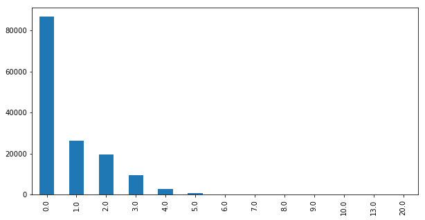

```python
plt.figure(figsize=(10, 5))
pd.value_counts(df.NumberOfDependents).plot(kind='bar');
```

```python
pd.crosstab(df.NumberOfTimes90DaysLate, df.SeriousDlqin2yrs) #过去有逾期90天以上还款的次数和后续两年内出现90天以上的还款逾期的关系
```

| SeriousDlqin2yrs NumberOfTimes90DaysLate | 0 | 1 |
| --- | --- | --- |
| 0 | 135108 | 6554 |
| 1 | 3478 | 1765 |
| 2 | 779 | 776 |
| 3 | 282 | 385 |
| 4 | 96 | 195 |
| 5 | 48 | 83 |
| 6 | 32 | 48 |
| 7 | 7 | 31 |
| 8 | 6 | 15 |
| 9 | 5 | 14 |
| 10 | 3 | 5 |
| 11 | 2 | 3 |
| 12 | 1 | 1 |
| 13 | 2 | 2 |
| 14 | 1 | 1 |
| 15 | 2 | 0 |
| 17 | 0 | 1 |
| 96 | 1 | 4 |
| 98 | 121 | 143 |

```python
pd.crosstab(df.age, df.NumberOfDependents) #年龄和需要抚养人数的关系
```

| NumberOfDependents age | 0.0 | 1.0 | 2.0 | 3.0 | 4.0 | 5.0 | 6.0 | 7.0 | 8.0 | 9.0 | 10.0 | 13.0 | 20.0 |
| --- | --- | --- | --- | --- | --- | --- | --- | --- | --- | --- | --- | --- | --- |
| 0 | 0 | 0 | 1 | 0 | 0 | 0 | 0 | 0 | 0 | 0 | 0 | 0 | 0 |
| 21 | 148 | 3 | 1 | 0 | 0 | 0 | 0 | 0 | 0 | 0 | 0 | 0 | 0 |
| 22 | 385 | 7 | 2 | 2 | 0 | 0 | 0 | 0 | 0 | 0 | 0 | 0 | 0 |
| 23 | 550 | 33 | 13 | 3 | 0 | 0 | 0 | 0 | 0 | 0 | 0 | 0 | 0 |
| 24 | 689 | 48 | 19 | 3 | 1 | 0 | 0 | 0 | 0 | 0 | 0 | 0 | 0 |
| 25 | 774 | 91 | 31 | 7 | 5 | 1 | 0 | 0 | 0 | 0 | 0 | 0 | 0 |
| 26 | 946 | 128 | 56 | 14 | 4 | 0 | 0 | 0 | 0 | 0 | 0 | 0 | 0 |
| 27 | 1001 | 192 | 53 | 32 | 4 | 0 | 0 | 0 | 0 | 0 | 0 | 0 | 0 |
| 28 | 1142 | 210 | 114 | 45 | 8 | 1 | 0 | 0 | 0 | 0 | 0 | 0 | 0 |
| 29 | 1195 | 254 | 145 | 53 | 14 | 1 | 1 | 0 | 0 | 0 | 0 | 0 | 0 |
| 30 | 1337 | 288 | 178 | 72 | 14 | 7 | 1 | 1 | 0 | 0 | 0 | 0 | 0 |
| 31 | 1314 | 344 | 245 | 91 | 18 | 4 | 0 | 0 | 0 | 0 | 0 | 0 | 0 |
| 32 | 1207 | 380 | 275 | 106 | 53 | 3 | 0 | 0 | 0 | 0 | 0 | 0 | 0 |
| 33 | 1254 | 449 | 315 | 140 | 50 | 10 | 2 | 0 | 0 | 0 | 0 | 0 | 0 |
| 34 | 1152 | 389 | 360 | 145 | 65 | 11 | 1 | 0 | 0 | 0 | 0 | 0 | 0 |
| 35 | 1136 | 418 | 398 | 184 | 58 | 15 | 3 | 1 | 1 | 0 | 0 | 0 | 0 |
| 36 | 1139 | 445 | 486 | 202 | 50 | 15 | 5 | 1 | 0 | 0 | 0 | 0 | 0 |
| 37 | 1088 | 488 | 541 | 274 | 77 | 18 | 2 | 0 | 0 | 1 | 0 | 0 | 0 |
| 38 | 1113 | 484 | 604 | 283 | 84 | 26 | 3 | 0 | 1 | 1 | 0 | 0 | 0 |
| 39 | 1202 | 544 | 691 | 383 | 111 | 27 | 4 | 1 | 1 | 0 | 1 | 0 | 0 |
| 40 | 1185 | 570 | 758 | 391 | 104 | 43 | 5 | 1 | 1 | 0 | 0 | 0 | 1 |
| 41 | 1193 | 517 | 791 | 445 | 113 | 30 | 4 | 0 | 1 | 0 | 0 | 0 | 0 |
| 42 | 1159 | 526 | 755 | 427 | 142 | 38 | 7 | 2 | 0 | 0 | 0 | 0 | 0 |
| 43 | 1205 | 556 | 789 | 431 | 156 | 33 | 9 | 4 | 1 | 0 | 1 | 0 | 0 |
| 44 | 1209 | 574 | 854 | 461 | 133 | 32 | 7 | 2 | 1 | 0 | 1 | 0 | 0 |
| 45 | 1363 | 608 | 828 | 457 | 165 | 35 | 11 | 3 | 0 | 0 | 0 | 0 | 0 |
| 46 | 1373 | 695 | 876 | 498 | 165 | 35 | 8 | 8 | 2 | 0 | 0 | 0 | 0 |
| 47 | 1439 | 672 | 863 | 491 | 148 | 46 | 9 | 0 | 2 | 0 | 1 | 0 | 0 |
| 48 | 1509 | 771 | 791 | 459 | 157 | 37 | 11 | 3 | 1 | 2 | 0 | 0 | 0 |
| 49 | 1632 | 717 | 790 | 439 | 143 | 46 | 8 | 6 | 1 | 0 | 0 | 0 | 0 |
| ... | ... | ... | ... | ... | ... | ... | ... | ... | ... | ... | ... | ... | ... |
| 74 | 1164 | 184 | 23 | 4 | 2 | 0 | 0 | 1 | 1 | 0 | 0 | 0 | 0 |
| 75 | 981 | 167 | 17 | 3 | 0 | 0 | 0 | 0 | 0 | 0 | 0 | 0 | 0 |
| 76 | 933 | 165 | 16 | 0 | 0 | 0 | 0 | 0 | 0 | 0 | 0 | 0 | 0 |
| 77 | 890 | 129 | 11 | 2 | 0 | 0 | 0 | 0 | 0 | 0 | 0 | 0 | 0 |
| 78 | 837 | 137 | 13 | 2 | 1 | 0 | 0 | 0 | 0 | 0 | 0 | 0 | 0 |
| 79 | 770 | 131 | 10 | 4 | 0 | 0 | 0 | 0 | 0 | 0 | 0 | 0 | 0 |
| 80 | 704 | 109 | 7 | 2 | 0 | 0 | 0 | 0 | 0 | 0 | 0 | 0 | 0 |
| 81 | 629 | 76 | 6 | 1 | 0 | 0 | 0 | 0 | 0 | 0 | 0 | 0 | 0 |
| 82 | 527 | 69 | 1 | 0 | 1 | 0 | 0 | 0 | 0 | 0 | 0 | 0 | 0 |
| 83 | 417 | 44 | 2 | 0 | 0 | 0 | 0 | 0 | 0 | 0 | 0 | 0 | 0 |
| 84 | 406 | 32 | 1 | 0 | 0 | 0 | 0 | 0 | 0 | 0 | 0 | 0 | 0 |
| 85 | 403 | 30 | 2 | 0 | 0 | 0 | 0 | 0 | 0 | 0 | 0 | 0 | 0 |
| 86 | 318 | 46 | 2 | 0 | 1 | 0 | 0 | 0 | 0 | 0 | 0 | 0 | 0 |
| 87 | 279 | 29 | 1 | 1 | 0 | 0 | 0 | 0 | 0 | 0 | 0 | 0 | 0 |
| 88 | 244 | 20 | 1 | 0 | 0 | 0 | 0 | 0 | 0 | 0 | 0 | 0 | 0 |
| 89 | 230 | 11 | 1 | 0 | 0 | 0 | 0 | 0 | 0 | 0 | 0 | 0 | 0 |
| 90 | 148 | 19 | 0 | 0 | 0 | 0 | 0 | 0 | 0 | 0 | 0 | 0 | 0 |
| 91 | 119 | 10 | 0 | 0 | 0 | 0 | 0 | 0 | 0 | 0 | 0 | 0 | 0 |
| 92 | 75 | 7 | 0 | 0 | 0 | 0 | 0 | 0 | 0 | 0 | 0 | 0 | 0 |
| 93 | 67 | 3 | 0 | 0 | 0 | 0 | 0 | 0 | 0 | 0 | 0 | 0 | 0 |
| 94 | 33 | 2 | 0 | 0 | 0 | 0 | 0 | 0 | 0 | 0 | 0 | 0 | 0 |
| 95 | 33 | 4 | 0 | 0 | 0 | 0 | 0 | 0 | 0 | 0 | 0 | 0 | 0 |
| 96 | 12 | 2 | 0 | 0 | 0 | 0 | 0 | 0 | 0 | 0 | 0 | 0 | 0 |
| 97 | 11 | 1 | 0 | 0 | 0 | 0 | 0 | 0 | 0 | 0 | 0 | 0 | 0 |
| 98 | 5 | 0 | 0 | 0 | 0 | 0 | 0 | 0 | 0 | 0 | 0 | 0 | 0 |
| 99 | 5 | 0 | 0 | 0 | 0 | 0 | 0 | 0 | 0 | 0 | 0 | 0 | 0 |
| 101 | 3 | 0 | 0 | 0 | 0 | 0 | 0 | 0 | 0 | 0 | 0 | 0 | 0 |
| 102 | 2 | 1 | 0 | 0 | 0 | 0 | 0 | 0 | 0 | 0 | 0 | 0 | 0 |
| 103 | 3 | 0 | 0 | 0 | 0 | 0 | 0 | 0 | 0 | 0 | 0 | 0 | 0 |
| 107 | 1 | 0 | 0 | 0 | 0 | 0 | 0 | 0 | 0 | 0 | 0 | 0 | 0 |

84 rows × 13 columns

#### （2）数据清理

```python
df.columns
```

```
Index(['SeriousDlqin2yrs', 'RevolvingUtilizationOfUnsecuredLines', 'age',
       'NumberOfTime30-59DaysPastDueNotWorse', 'DebtRatio', 'MonthlyIncome',
       'NumberOfOpenCreditLinesAndLoans', 'NumberOfTimes90DaysLate',
       'NumberRealEstateLoansOrLines', 'NumberOfTime60-89DaysPastDueNotWorse',
       'NumberOfDependents'],
      dtype='object')
```

```python
from sklearn.neighbors import KNeighborsRegressor
income_imputer = KNeighborsRegressor(n_neighbors=1) #n_neighbors即KNN中的K值

# 把数据分为两部分，有缺失的和无缺失的，用无缺失的数据建立模型来判断缺失数据的可能取值
train_monthly_income = df[df.MonthlyIncome.isnull()==False]
train_null_monthly_income = df[df.MonthlyIncome.isnull()==True]
```

```python
# 用房贷的信贷次数、包括车贷房贷在内的贷款笔数和年龄来训练月收入
cols = ['NumberRealEstateLoansOrLines', 'NumberOfOpenCreditLinesAndLoans', 'age']
income_imputer.fit(train_monthly_income[cols], train_monthly_income.MonthlyIncome)
```

```
KNeighborsRegressor(algorithm='auto', leaf_size=30, metric='minkowski',
          metric_params=None, n_jobs=1, n_neighbors=1, p=2,
          weights='uniform')
```

```python
new_values = income_imputer.predict(train_null_monthly_income[cols])
train_null_monthly_income.ix[:, 'MonthlyIncome'] = new_values #填充月收入缺失值
```

```python
new_values
```

```
array([ 2600.,  2240.,  4590., ...,  5756.,  4891.,  8108.])
```

```python
df_imputed = train_monthly_income.append(train_null_monthly_income)
df_imputed.shape
```

```
(150000, 11)
```

```python
df_imputed.ix[df_imputed.NumberOfDependents.isnull(),'NumberOfDependents'] = -1 #填充需要抚养人数缺失值
```

```python
df_imputed.info()
```

```
<class 'pandas.core.frame.DataFrame'>
Int64Index: 150000 entries, 0 to 149997
Data columns (total 11 columns):
SeriousDlqin2yrs                        150000 non-null int64
RevolvingUtilizationOfUnsecuredLines    150000 non-null float64
age                                     150000 non-null int64
NumberOfTime30-59DaysPastDueNotWorse    150000 non-null int64
DebtRatio                               150000 non-null float64
MonthlyIncome                           150000 non-null float64
NumberOfOpenCreditLinesAndLoans         150000 non-null int64
NumberOfTimes90DaysLate                 150000 non-null int64
NumberRealEstateLoansOrLines            150000 non-null int64
NumberOfTime60-89DaysPastDueNotWorse    150000 non-null int64
NumberOfDependents                      150000 non-null float64
dtypes: float64(4), int64(7)
memory usage: 13.7 MB
```

#### （3）特征工程

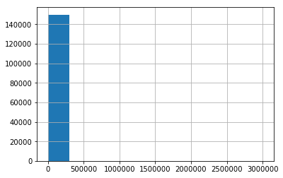

```python
df_imputed.MonthlyIncome.hist() #个别高收入群体拉高了平均值
```

```python
df_imputed.ix[df_imputed.MonthlyIncome > 15000, 'MonthlyIncome'].count()
```

```
6391
```

```python
def cap_values(x, cap):
    if x > cap:
        return cap
    else:
        return x
# 设定上限
df_imputed.MonthlyIncome = df_imputed.MonthlyIncome.apply(lambda x: cap_values(x, 15000))
```

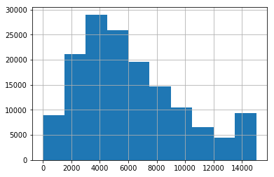

```python
df_imputed.MonthlyIncome.hist()
```

```python
# 月收入离散化
df_imputed['income_bins'] = pd.cut(df_imputed.MonthlyIncome, bins=15, labels=False)
pd.value_counts(df_imputed.income_bins)
```

```
4     19350
3     19219
2     17020
5     16450
6     12837
7     11130
1      9076
8      9061
14     8199
9      7336
0      6146
10     5654
11     3606
12     2966
13     1950
Name: income_bins, dtype: int64
```

```python
df_imputed.ix[df_imputed.income_bins == 13, 'MonthlyIncome'].head()
```

```
13     13700.0
55     13793.0
123    14000.0
239    14000.0
295    13054.0
Name: MonthlyIncome, dtype: float64
```

```python
# 按月收入分类计算出现逾期平均值
df_imputed[["income_bins", "SeriousDlqin2yrs"]].groupby("income_bins").mean()
```

| income_bins | SeriousDlqin2yrs |
| --- | --- |
| 0 | 0.058737 |
| 1 | 0.100705 |
| 2 | 0.089600 |
| 3 | 0.082783 |
| 4 | 0.070956 |
| 5 | 0.065593 |
| 6 | 0.060217 |
| 7 | 0.054268 |
| 8 | 0.050988 |
| 9 | 0.050164 |
| 10 | 0.042448 |
| 11 | 0.039933 |
| 12 | 0.040121 |
| 13 | 0.040513 |
| 14 | 0.048055 |

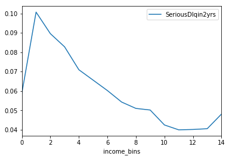

```python
cols = ["income_bins", "SeriousDlqin2yrs"]
df_imputed[cols].groupby("income_bins").mean().plot();
```

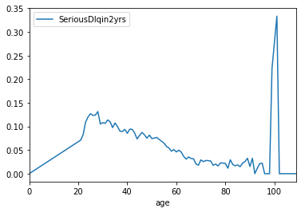

```python
# 按年龄计算出现逾期平均值
cols = ['age', 'SeriousDlqin2yrs']
df_imputed[cols].groupby("age").mean().plot();
```

```python
df_imputed['age_bin'] = pd.cut(df_imputed.age, bins=[0] + list(range(20, 80, 5)) + [120])
df_imputed['age_bin'].value_counts()
```

```
(45, 50]     18829
(50, 55]     17861
(55, 60]     16945
(60, 65]     16461
(40, 45]     16208
(35, 40]     13611
(65, 70]     10963
(30, 35]     10728
(75, 120]    10129
(25, 30]      7730
(70, 75]      7507
(20, 25]      3027
(0, 20]          0
Name: age_bin, dtype: int64
```

```python
#月收入标准化
from sklearn.preprocessing import StandardScaler
df_imputed['monthly_income_scaled'] = StandardScaler().fit_transform(df_imputed.MonthlyIncome.values.reshape(-1,1))
df_imputed['monthly_income_scaled'].head()
```

```
0    0.823997
1   -0.944376
2   -0.824496
3   -0.754520
4    2.418788
Name: monthly_income_scaled, dtype: float64
```

#### （4）建模和评估

```python
df_imputed.columns
```

```
Index(['SeriousDlqin2yrs', 'RevolvingUtilizationOfUnsecuredLines', 'age',
       'NumberOfTime30-59DaysPastDueNotWorse', 'DebtRatio', 'MonthlyIncome',
       'NumberOfOpenCreditLinesAndLoans', 'NumberOfTimes90DaysLate',
       'NumberRealEstateLoansOrLines', 'NumberOfTime60-89DaysPastDueNotWorse',
       'NumberOfDependents', 'income_bins', 'age_bin',
       'monthly_income_scaled'],
      dtype='object')
```

```python
# 特征选取
features = ['RevolvingUtilizationOfUnsecuredLines',
 'age',
 'NumberOfTime30-59DaysPastDueNotWorse',
 'DebtRatio',
 'NumberOfOpenCreditLinesAndLoans',
 'NumberOfTimes90DaysLate',
 'NumberRealEstateLoansOrLines',
 'NumberOfTime60-89DaysPastDueNotWorse',
 'NumberOfDependents',
 'income_bins',
 'age_bin',
 'monthly_income_scaled']
```

```python
X = pd.get_dummies(df_imputed[features], columns = ['income_bins', 'age_bin'])
```

```python
X.info()
```

```
<class 'pandas.core.frame.DataFrame'>
Int64Index: 150000 entries, 0 to 149997
Data columns (total 38 columns):
RevolvingUtilizationOfUnsecuredLines    150000 non-null float64
age                                     150000 non-null int64
NumberOfTime30-59DaysPastDueNotWorse    150000 non-null int64
DebtRatio                               150000 non-null float64
NumberOfOpenCreditLinesAndLoans         150000 non-null int64
NumberOfTimes90DaysLate                 150000 non-null int64
NumberRealEstateLoansOrLines            150000 non-null int64
NumberOfTime60-89DaysPastDueNotWorse    150000 non-null int64
NumberOfDependents                      150000 non-null float64
monthly_income_scaled                   150000 non-null float64
income_bins_0                           150000 non-null uint8
income_bins_1                           150000 non-null uint8
income_bins_2                           150000 non-null uint8
income_bins_3                           150000 non-null uint8
income_bins_4                           150000 non-null uint8
income_bins_5                           150000 non-null uint8
income_bins_6                           150000 non-null uint8
income_bins_7                           150000 non-null uint8
income_bins_8                           150000 non-null uint8
income_bins_9                           150000 non-null uint8
income_bins_10                          150000 non-null uint8
income_bins_11                          150000 non-null uint8
income_bins_12                          150000 non-null uint8
income_bins_13                          150000 non-null uint8
income_bins_14                          150000 non-null uint8
age_bin_(0, 20]                         150000 non-null uint8
age_bin_(20, 25]                        150000 non-null uint8
age_bin_(25, 30]                        150000 non-null uint8
age_bin_(30, 35]                        150000 non-null uint8
age_bin_(35, 40]                        150000 non-null uint8
age_bin_(40, 45]                        150000 non-null uint8
age_bin_(45, 50]                        150000 non-null uint8
age_bin_(50, 55]                        150000 non-null uint8
age_bin_(55, 60]                        150000 non-null uint8
age_bin_(60, 65]                        150000 non-null uint8
age_bin_(65, 70]                        150000 non-null uint8
age_bin_(70, 75]                        150000 non-null uint8
age_bin_(75, 120]                       150000 non-null uint8
dtypes: float64(4), int64(6), uint8(28)
memory usage: 16.6 MB
```

```python
X.head()
```

|  | RevolvingUtilizationOfUnsecuredLines | age | NumberOfTime30-59DaysPastDueNotWorse | DebtRatio | NumberOfOpenCreditLinesAndLoans | NumberOfTimes90DaysLate | NumberRealEstateLoansOrLines | NumberOfTime60-89DaysPastDueNotWorse | NumberOfDependents | monthly_income_scaled | ... | age_bin_(30, 35] | age_bin_(35, 40] | age_bin_(40, 45] | age_bin_(45, 50] | age_bin_(50, 55] | age_bin_(55, 60] | age_bin_(60, 65] | age_bin_(65, 70] | age_bin_(70, 75] | age_bin_(75, 120] |
| --- | --- | --- | --- | --- | --- | --- | --- | --- | --- | --- | --- | --- | --- | --- | --- | --- | --- | --- | --- | --- | --- |
| 0 | 0.766127 | 45 | 2 | 0.802982 | 13 | 0 | 6 | 0 | 2.0 | 0.823997 | ... | 0 | 0 | 1 | 0 | 0 | 0 | 0 | 0 | 0 | 0 |
| 1 | 0.957151 | 40 | 0 | 0.121876 | 4 | 0 | 0 | 0 | 1.0 | -0.944376 | ... | 0 | 1 | 0 | 0 | 0 | 0 | 0 | 0 | 0 | 0 |
| 2 | 0.658180 | 38 | 1 | 0.085113 | 2 | 1 | 0 | 0 | 0.0 | -0.824496 | ... | 0 | 1 | 0 | 0 | 0 | 0 | 0 | 0 | 0 | 0 |
| 3 | 0.233810 | 30 | 0 | 0.036050 | 5 | 0 | 0 | 0 | 0.0 | -0.754520 | ... | 0 | 0 | 0 | 0 | 0 | 0 | 0 | 0 | 0 | 0 |
| 4 | 0.907239 | 49 | 1 | 0.024926 | 7 | 0 | 1 | 0 | 0.0 | 2.418788 | ... | 0 | 0 | 0 | 1 | 0 | 0 | 0 | 0 | 0 | 0 |

5 rows × 38 columns

```python
y = df_imputed.SeriousDlqin2yrs
```

```python
#将数据集分为训练集和测试集两个部分
from sklearn.model_selection import train_test_split
train_X, test_X, train_y, test_y = train_test_split(X, y ,train_size=0.7,random_state=1)
```

```python
train_X.shape
```

```
(105000, 38)
```

```python
test_X.shape
```

```
(45000, 38)
```

```python
from sklearn.linear_model import LogisticRegression

clf = LogisticRegression() #使用逻辑回归进行训练
clf.fit(train_X, train_y)
```

```
LogisticRegression(C=1.0, class_weight=None, dual=False, fit_intercept=True,
          intercept_scaling=1, max_iter=100, multi_class='ovr', n_jobs=1,
          penalty='l2', random_state=None, solver='liblinear', tol=0.0001,
          verbose=0, warm_start=False)
```

```python
pred_y = clf.predict(test_X)
pred_y
```

```
array([0, 0, 0, ..., 0, 0, 0])
```

```python
#模型评估
from sklearn.metrics import confusion_matrix, classification_report, roc_auc_score, roc_curve
confusion_matrix(test_y, pred_y)
```

```
array([[41871,    97],
       [ 2894,   138]])
```

```python
print (classification_report(test_y, pred_y, labels=[0, 1]))
```

```
             precision    recall  f1-score   support

          0       0.94      1.00      0.97     41968
          1       0.59      0.05      0.08      3032

avg / total       0.91      0.93      0.91     45000
```

Precision: $P=\frac{TP}{(TP+FP)}$ Recall: $R=\frac{TP}{(TP+FN)}$ F1-score: $F1=\frac{2TP}{2TP+FP+FN}$

```python
pred_proba_y = clf.predict_proba(test_X)
pred_proba_y
```

```
array([[ 0.92293196,  0.07706804],
       [ 0.967963  ,  0.032037  ],
       [ 0.97467657,  0.02532343],
       ...,
       [ 0.9628152 ,  0.0371848 ],
       [ 0.86371942,  0.13628058],
       [ 0.97499501,  0.02500499]])
```

```python
roc_auc_score(test_y, pred_proba_y[:, 1])
```

```
0.70926700450626035
```

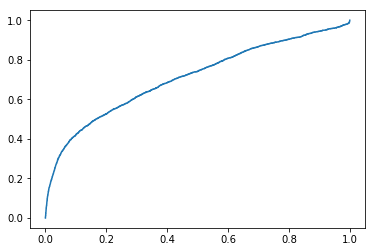

```python
fpr, tpr, thresholds = roc_curve(test_y, pred_proba_y[:, 1])
plt.plot(fpr, tpr)
```